# Reproducible Research: Peer Assessment 1

Hankang

December 11, 2014

```r
# set global chunk options:
library(knitr)
library(plyr)
library(dplyr)
```

```r
library(ggplot2)
opts_chunk$set(fig.align='center', echo = TRUE)
```

## 1. Loading and preprocessing the data

```r
unzip("activity.zip")
df <-  read.csv("activity.csv", sep = ",")
```

## 2. What is mean total number of steps taken per day?

- 1 Make a histogram of the total number of steps taken each day

```r
df.steps <- ddply(df, .(date), summarize, total = sum(steps, na.rm = T))
```

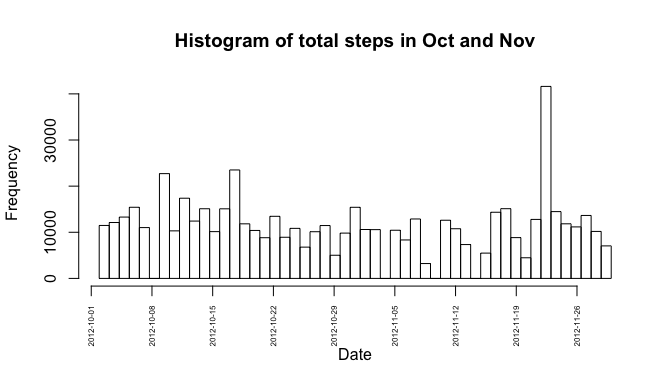

```r
df.steps.hist <- as.POSIXlt(with(df.steps,rep(date,total)))
hist(df.steps.hist, "weeks", breaks = 61, freq = T, xlab = "Date",main = "Histogram of total steps in Oct and Nov", xaxt = "n")
axis.POSIXct(1, at=seq(as.POSIXlt("2012-10-01"), as.POSIXlt("2012-11-30"), by="1 weeks"), format="%Y-%m-%d",las=2, cex.axis = 0.5)
```

- 2 Calculate and report the mean and median total number of steps taken per day

```r
df.summary <- ddply(df, .(date), summarize, mean = mean(steps, na.rm = T), median = median(steps, na.rm = T))
print(df.summary)
```

```
##          date       mean median
## 1  2012-10-01        NaN     NA
## 2  2012-10-02  0.4375000      0
## 3  2012-10-03 39.4166667      0
## 4  2012-10-04 42.0694444      0
## 5  2012-10-05 46.1597222      0
## 6  2012-10-06 53.5416667      0
## 7  2012-10-07 38.2465278      0
## 8  2012-10-08        NaN     NA
## 9  2012-10-09 44.4826389      0
## 10 2012-10-10 34.3750000      0
## 11 2012-10-11 35.7777778      0
## 12 2012-10-12 60.3541667      0
## 13 2012-10-13 43.1458333      0
## 14 2012-10-14 52.4236111      0
```

[output cut: 47 more lines]

wired summary… possibly too manmy zeros in the data, try no include “0” or “NA” ?

```r
df.NA = df[df$steps != 0 & !is.na(df$steps),]

df.summary.NA <- ddply(df.NA, .(date), summarize, mean = mean(steps, na.rm = T), median = median(steps, na.rm = T))
print(df.summary.NA)
```

```
##          date      mean median
## 1  2012-10-02  63.00000   63.0
## 2  2012-10-03 140.14815   61.0
## 3  2012-10-04 121.16000   56.5
## 4  2012-10-05 154.58140   66.0
## 5  2012-10-06 145.47170   67.0
## 6  2012-10-07 101.99074   52.5
## 7  2012-10-09 134.85263   48.0
## 8  2012-10-10  95.19231   56.5
## 9  2012-10-11 137.38667   35.0
## 10 2012-10-12 156.59459   46.0
## 11 2012-10-13 119.48077   45.5
## 12 2012-10-14 160.61702   60.5
## 13 2012-10-15 131.67532   54.0
## 14 2012-10-16 157.12500   64.0
```

[output cut: 39 more lines]

**NOTE:** *Much better, but we can see we only have 53 dates data!*

## What is the average daily activity pattern?

- 1 Make a time series plot (i.e. `type = "l"`) of the 5-minute interval (x-axis) and the average number of steps taken, averaged across all days (y-axis)

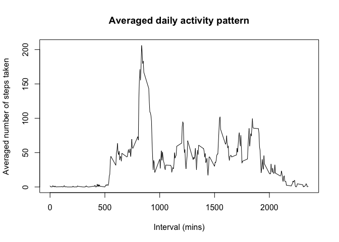

```r
df.average <- ddply(df, .(interval), summarize, mean = mean(steps, na.rm = T))

with(df.average, plot(interval, mean, type = "l",xlab = "Interval (mins)", ylab = "Averaged number of steps taken",main = "Averaged daily activity pattern"))
```

- 2 Which 5-minute interval, on average across all the days in the dataset, contains the maximum number of steps?

```r
with(df.average, interval[which(mean == max(mean))])
```

```
## [1] 835
```

## Imputing missing values

- 1 Calculate and report the total number of missing values in the dataset (i.e. the total number of rows with `NA`s)

```r
NAtotal <- sum(is.na(df$steps))
print(NAtotal)
```

```
## [1] 2304
```

- 2 Devise a strategy for filling in all of the missing values in the dataset. The strategy does not need to be sophisticated. For example, you could use the mean/median for that day, or the mean for that 5-minute interval, etc.

  **Using mean for that 5-minute interval**
- 3 Create a new dataset that is equal to the original dataset but with the missing data filled in.

```r
temp <- merge(df, df.average, by = "interval")
temp$steps[is.na(temp$steps)] <- temp$mean[is.na(temp$steps)]

imputed <- temp %>%
    arrange(date, interval) %>%
    select(steps, date, interval)

imputed.steps.total <- ddply(imputed, .(date), summarize,
                       total = sum(steps))
```

- 4 Make a histogram of the total number of steps taken each day and Calculate and report the mean and median total number of steps taken per day. Do these values differ from the estimates from the first part of the assignment? What is the impact of imputing missing data on the estimates of the total daily number of steps?

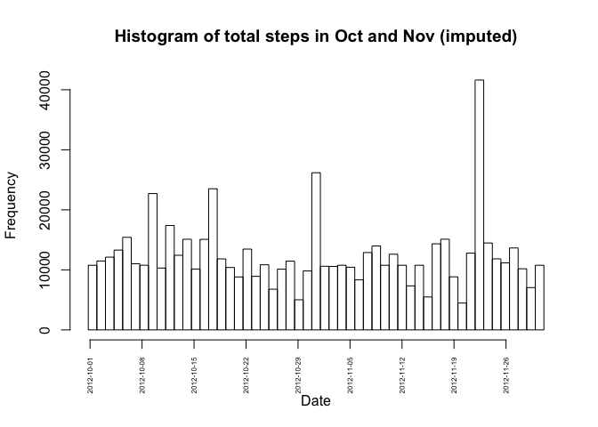

```r
imputed.steps.hist <- as.POSIXct(rep(imputed.steps.total$date,
                      imputed.steps.total$total))

hist(imputed.steps.hist, "weeks", breaks = 61, freq = T, xlab = "Date",
     main = "Histogram of total steps in Oct and Nov (imputed)", xaxt = "n")
axis.POSIXct(1, at=seq(as.POSIXlt("2012-10-01"), as.POSIXlt("2012-11-30"),
                       by="1 weeks"), format="%Y-%m-%d",las=2, cex.axis = 0.5)
```

*Mean and media*

```r
## report mean and media
imputed.summary <- ddply(imputed , .(date), summarize,
                 mean = mean(steps, na.rm = T),
                 median = median(steps, na.rm = T))
print(imputed.summary)
```

```
##          date       mean   median
## 1  2012-10-01 37.3825996 34.11321
## 2  2012-10-02  0.4375000  0.00000
## 3  2012-10-03 39.4166667  0.00000
## 4  2012-10-04 42.0694444  0.00000
## 5  2012-10-05 46.1597222  0.00000
## 6  2012-10-06 53.5416667  0.00000
## 7  2012-10-07 38.2465278  0.00000
## 8  2012-10-08 37.3825996 34.11321
## 9  2012-10-09 44.4826389  0.00000
## 10 2012-10-10 34.3750000  0.00000
## 11 2012-10-11 35.7777778  0.00000
## 12 2012-10-12 60.3541667  0.00000
## 13 2012-10-13 43.1458333  0.00000
## 14 2012-10-14 52.4236111  0.00000
```

[output cut: 47 more lines]

```r
# remove zero
imputed1 = imputed[imputed$steps != 0,]

imputed.summary1 <- ddply(imputed1, .(date), summarize,
                  mean = mean(steps, na.rm = T),
                  median = median(steps, na.rm = T))
print(imputed.summary1)
```

```
##          date      mean    median
## 1  2012-10-01  40.02301  37.45283
## 2  2012-10-02  63.00000  63.00000
## 3  2012-10-03 140.14815  61.00000
## 4  2012-10-04 121.16000  56.50000
## 5  2012-10-05 154.58140  66.00000
## 6  2012-10-06 145.47170  67.00000
## 7  2012-10-07 101.99074  52.50000
## 8  2012-10-08  40.02301  37.45283
## 9  2012-10-09 134.85263  48.00000
## 10 2012-10-10  95.19231  56.50000
## 11 2012-10-11 137.38667  35.00000
## 12 2012-10-12 156.59459  46.00000
## 13 2012-10-13 119.48077  45.50000
## 14 2012-10-14 160.61702  60.50000
```

[output cut: 47 more lines]

*visulize the difference*

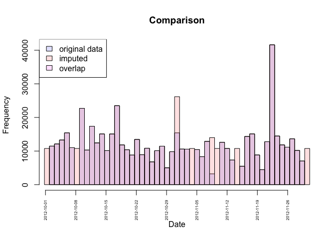

```r
h1 <- hist(df.steps.hist, breaks = 61, freq = F, plot = F)
h2 <- hist(imputed.steps.hist, breaks = 61, freq = F,xaxt = "n",
           plot = F)
plot(h1, col=rgb(0,0,1,1/8), xaxt = "n",main="Comparison", xlab="Date", ylab="Frequency")
plot(h2, col=rgb(1,0,0,1/8), add=T)

axis.POSIXct(1, at=seq(as.POSIXlt("2012-10-01"), as.POSIXlt("2012-11-30"),
                      by="1 weeks"), format="%Y-%m-%d",las=2, cex.axis = 0.5)
legend("topleft", c("original data","imputed", "overlap"),
       fill = c(rgb(0,0,1,1/8), rgb(1,0,0,1/8),rgb(1,0,1,1/8)))
```

**Explanation:** The `NA` was replaced by the mean of 5-minute interval which rised the interval value of those contained `NA` but remained those did not contain `NA` the same. That’s why most of the histogram is overlaped.

## Are there differences in activity patterns between weekdays and weekends?

- 1 Create a new factor variable in the dataset with two levels – “weekday” and “weekend” indicating whether a given date is a weekday or weekend day.

```r
weekdays <- as.POSIXlt(df$date)$wday
df.weekday <- cbind(df, weekdays)

df.weekday$weekdays[which(df.weekday$weekdays %in% c(1:5))] <- "weekday"
df.weekday$weekdays[which(df.weekday$weekdays %in% c(0,6))] <- "weekend"
df.weekday$weekdays <- as.factor(df.weekday$weekdays)
```

- 2 Make a panel plot containing a time series plot (i.e. type = “l”) of the 5-minute interval (x-axis) and the average number of steps taken, averaged across all weekday days or weekend days (y-axis). See the README file in the GitHub repository to see an example of what this plot should look like using simulated data.

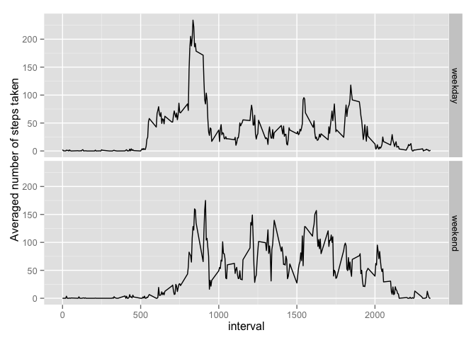

```r
weekday.summary <- ddply(df.weekday, .(interval,weekdays), summarize,
                         mean = mean(steps, na.rm = T))
qplot(interval, mean, data = weekday.summary, facets = weekdays ~ ., geom = "path",
      ylab = "Averaged number of steps taken")
```